# Between Bursts of Focus

## A Portrait of my productivity in YouTube time

We often imagine productivity as a solid block of uninterrupted effort - but in reality it flows im bursts, stutters and loops. Between focus sessions, small digital rituals creep in. This report examines how my YouTube viewing habits mirror the rhythms of my productivity. Rather than seeing these moments as distractions, I explore how they mark transitions between mental states - boredom, focus, procrastination and relief. What emerges isn’t just data about videos, but a portrait of my life drawn in timestamps, habits and fleeting motivations.

## Boredom and long afternoons

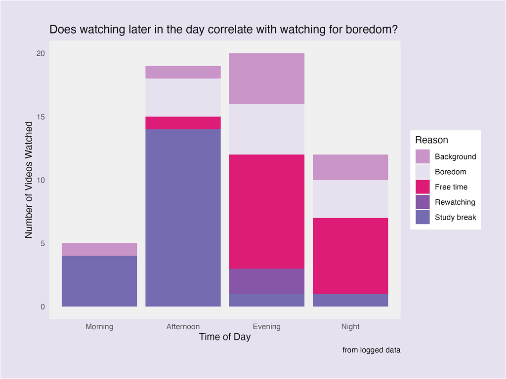

TLDR,

- **Does watching later in the day correlate to boredom?**: yes

## My most productive days

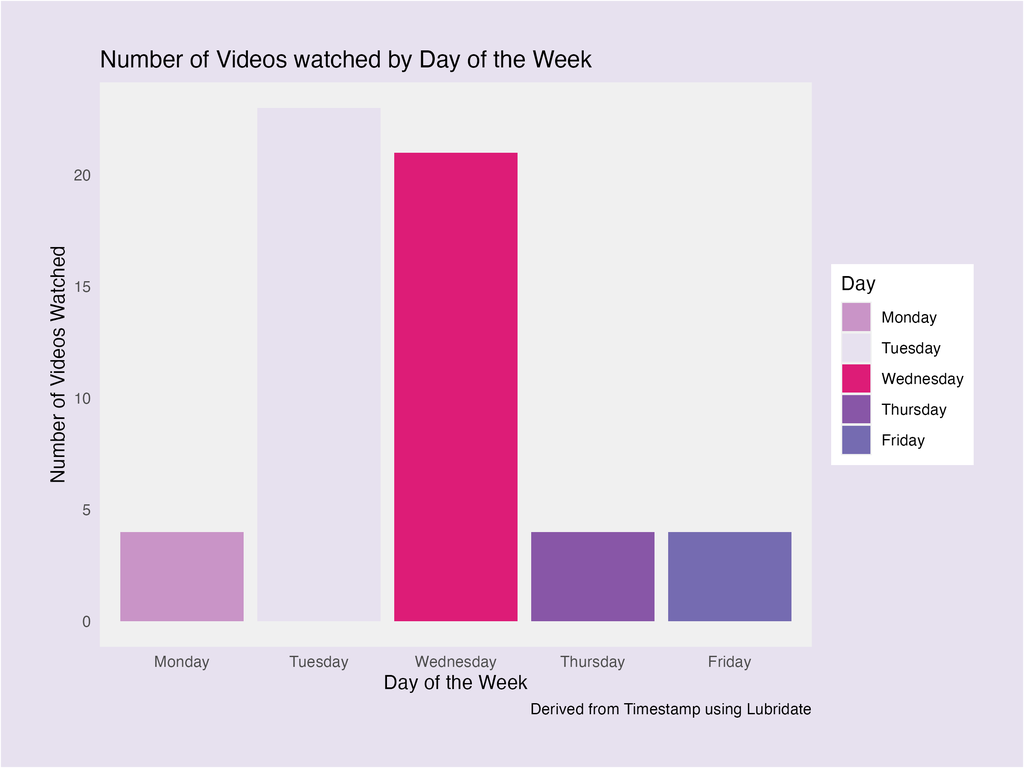

Tuesdays was the day I watched the most videos - but paradoxically, they were also among my most productive. This pattern reflects how intense study days often need pressure-release valves. Watching videos on Tuesday and Wednesdays might not signal avoidance, but recovery. Mondays were slower to start. Thursdays and Fridays faded out - but the middle of the week surged with energy and effort. TLDR,

- **Most productive day?**: Tuesday

## Distracted…

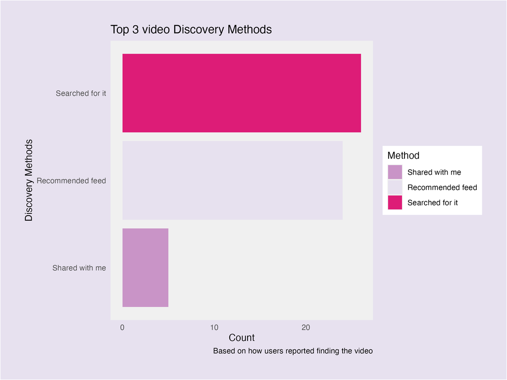

Distraction isn’t always aimless. In my case. it often came with a soundtrack. When distracted, I searched ip spevific videos - videos that stuck in my mind like earworms while i tried to study. This highlights the inner tug-of-war between focus and indulgence. The first 10 minutes of study are always the hardest - where i try to overwrite distraction with intention. Regardless of whether I succeed, my cooing mechanism is suprisinglky consistent: search for the video that matches the mental itch.

TLDR,

- **What was I doing while distracted?**: Searching up YT videos

## Closing Reflectionn

watching videos isn’t the opposite of working - its a parallel behaviour that pulses with meaning. These patterns don’t just show where my time went, but what I needed in those moments: stimulation, comfort, novelty or rest. By visualising my viewing behaviour, I’ve gained insight not just into my media habits, but into how i move through my days - trying to focus, slipping into distraction and making peace with both.